# DS4P: Visualizing Relationships Between Variables

## Using Facets to Reveal Patterns

### Examining Patterns by Genre

Do critics and audiences disagree more for certain types of movies? Let’s use faceting to find out:

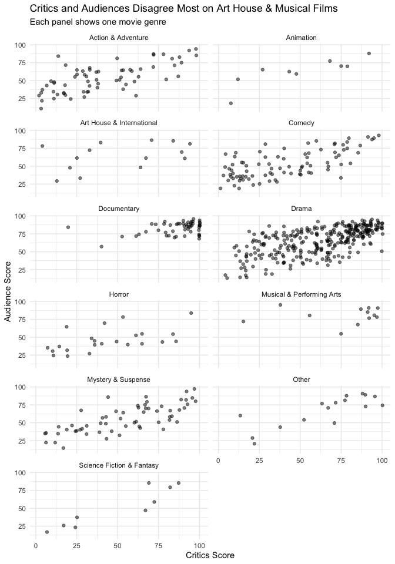

```r
# Convert genre to factor
MovieData$genre <- as.factor(MovieData$genre)

# Create faceted scatterplot
ggplot(data = MovieData) +
  geom_point(aes(x = critics_score, y = audience_score),
             position = "jitter", alpha = 0.5) +
  facet_wrap(~genre, ncol = 2) +
  labs(
    x = "Critics Score",
    y = "Audience Score",
    title = "Critics and Audiences Disagree Most on Art House & Musical Films",
    subtitle = "Each panel shows one movie genre"
  ) +
  theme_minimal()
```

### Adding Color for a Fourth Variable

Let’s add MPAA rating as color to see if movie ratings affect the critic-audience relationship:

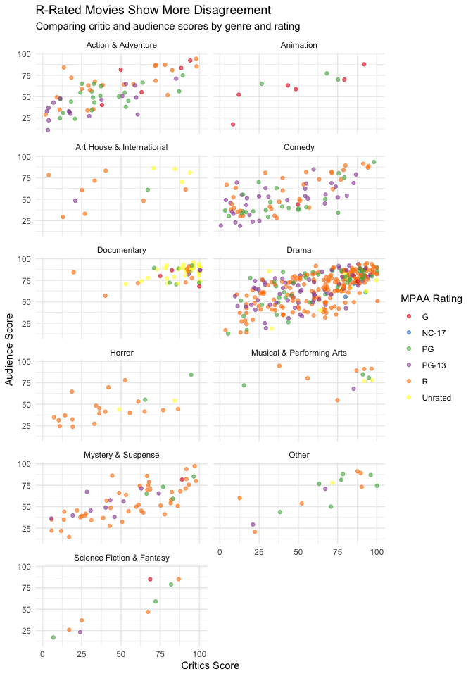

```r
# Convert MPAA rating to factor
MovieData$mpaa_rating <- as.factor(MovieData$mpaa_rating)

# Faceted plot with color
ggplot(data = MovieData) +
  geom_point(aes(x = critics_score, y = audience_score,
                 color = mpaa_rating),
             position = "jitter", alpha = 0.6) +
  facet_wrap(~genre, ncol = 2) +
  labs(
    x = "Critics Score",
    y = "Audience Score",
    color = "MPAA Rating",
    title = "R-Rated Movies Show More Disagreement",
    subtitle = "Comparing critic and audience scores by genre and rating"
  ) +
  theme_minimal() +
  scale_color_brewer(palette = "Set1")
```

We’re now encoding four variables:

1. **x position**: Critics score
2. **y position**: Audience score
3. **color**: MPAA rating (inside `aes()` to map data to colors)
4. **facets**: Genre

New elements:

- `color = mpaa_rating` inside `aes()` maps each rating to a different color
- `scale_color_brewer(palette = "Set1")` uses a ColorBrewer palette
  - These palettes are designed for clarity and colorblind-friendliness
- Notice how the legend title matches our `color = "MPAA Rating"` label

## Choosing the Right Visualization

### Decision Framework

When visualizing relationships between variables, consider:

**Use boxplots when:**

- One variable is categorical, one is continuous
- You want to compare distributions
- You need to show outliers
- Groups have unequal sizes

**Use scatterplots when:**

- Both variables are continuous
- You want to see the form of the relationship
- Individual observations matter
- You’re looking for patterns or clusters

**Use faceting when:**

- You need to compare patterns across groups
- The relationship might differ by subgroup
- You have a moderating third variable
- One plot would be too cluttered

### Best Practices for Multi-Variable Plots

1. **Start simple, add complexity gradually**
   - First create the basic relationship
   - Add color only if it reveals something new
   - Use facets when groups obscure each other
2. **Maintain visual hierarchy**
   - Your main comparison should be most prominent
   - Secondary variables should enhance, not distract
   - Use muted colors for less important distinctions
3. **Consider your audience**
   - More variables = more cognitive load
   - Include clear titles that state the finding
   - Make legends and labels crystal clear
4. **Test different approaches**
   - Try both color and faceting
   - Experiment with transparency and jittering
   - Ask: “What story is clearest?”

## Summary

Visualizing relationships requires choosing the right tool for your data:

- **Boxplots** excel at comparing continuous distributions across categories
- **Scatterplots** reveal relationships between continuous variables
- **Faceting** allows detailed comparisons across subgroups
- **Color and shape** can encode additional variables, but use judiciously

The key is to build visualizations layer by layer:

1. Start with the core relationship
2. Add visual elements that enhance understanding
3. Use facets when single plots become cluttered
4. Always prioritize clarity over complexity

Remember: The goal isn’t to impress with complicated graphics, but to reveal patterns that lead to understanding.

## Study Questions

### Understanding Plot Types

1. What are the five key pieces of information shown in a boxplot? How do you interpret each one?
2. Why might overlapping points be a problem in a scatterplot? What are two ways to address this issue?
3. You have data on voter turnout (continuous, 0-100%) and education level (categorical: “High School”, “College”, “Graduate”). Which type of plot would you use and why?
4. Write the ggplot2 code to create a boxplot showing income (y-axis) by political party (x-axis), with different colors for gender.

### Using Facets

5. What does `facet_wrap(~variable)` do? What does the tilde (~) symbol mean in this context?
6. When would you use `facet_wrap()` instead of just using color to distinguish groups?

### Interpreting Visualizations

7. In the Congress age boxplot showing both chambers and incumbency, what are three key insights you can draw?
8. Looking at the movie scatterplot, what does it mean when a point falls far above the diagonal line? Far below?

### Practical Applications

9. You want to explore whether the relationship between campaign spending and vote share differs by type of election (primary vs. general). Describe the visualization you would create.

### Code Challenges

10. Modify this scatterplot code to add 30% transparency and use faceting by `mpaa_rating`:

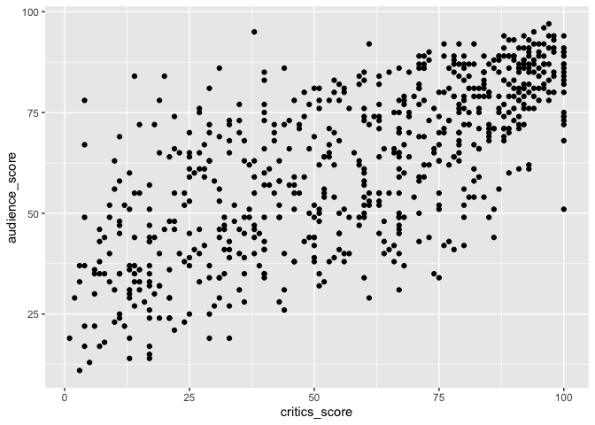

    ```r
    ggplot(data = MovieData) +
      geom_point(aes(x = critics_score, y = audience_score))
    ```